# Reproducible Research Peer Assessment 1

James C. Birk

January 12, 2018

## Initial Setup and Preprocessing of our assignment data

```r
library(dplyr)
library(lattice)
activityData<- read.csv("C://Users/James/Documents/R/activity.csv")
summary(activityData)
```

```
##      steps                date          interval
##  Min.   :  0.00   2012-10-01:  288   Min.   :   0.0
##  1st Qu.:  0.00   2012-10-02:  288   1st Qu.: 588.8
##  Median :  0.00   2012-10-03:  288   Median :1177.5
##  Mean   : 37.38   2012-10-04:  288   Mean   :1177.5
##  3rd Qu.: 12.00   2012-10-05:  288   3rd Qu.:1766.2
##  Max.   :806.00   2012-10-06:  288   Max.   :2355.0
##  NA's   :2304     (Other)   :15840
```

I also want to see the structure of the data as well as the header.

```r
str(activityData)
```

```
## 'data.frame':    17568 obs. of  3 variables:
##  $ steps   : int  NA NA NA NA NA NA NA NA NA NA ...
##  $ date    : Factor w/ 61 levels "2012-10-01","2012-10-02",..: 1 1 1 1 1 1 1 1 1 1 ...
##  $ interval: int  0 5 10 15 20 25 30 35 40 45 ...
```

```r
head(activityData)
```

```
##   steps       date interval
## 1    NA 2012-10-01        0
## 2    NA 2012-10-01        5
## 3    NA 2012-10-01       10
## 4    NA 2012-10-01       15
## 5    NA 2012-10-01       20
## 6    NA 2012-10-01       25
```

I have three elements, and I see that the dates are currently coded as factors and not as dates, so I fix that next.

```r
activityData$date<- as.Date(activityData$date)
str(activityData)
```

```
## 'data.frame':    17568 obs. of  3 variables:
##  $ steps   : int  NA NA NA NA NA NA NA NA NA NA ...
##  $ date    : Date, format: "2012-10-01" "2012-10-01" ...
##  $ interval: int  0 5 10 15 20 25 30 35 40 45 ...
```

Make a histogram and display it:

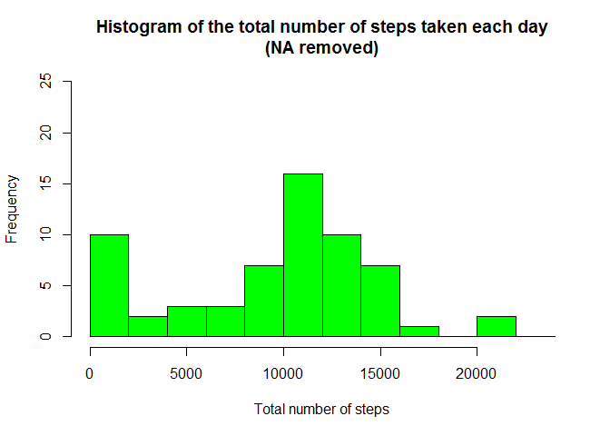

```r
sum_steps<-aggregate(activityData$steps, by=list(activityData$date), FUN=sum, na.rm=TRUE)
names(sum_steps)<- c("date", "total")
hist(sum_steps$total,
     breaks=seq(from=0, to=25000, by=2000),
     col="green",
     xlab="Total number of steps",
     ylim=c(0, 25),
     main="Histogram of the total number of steps taken each day\n(NA removed)")
```

```r
mean(sum_steps$total)
```

```
## [1] 9354.23
```

```r
median(sum_steps$total)
```

```
## [1] 10395
```

## What is the average daily activity pattern? Which 5-minute interval,on average across all the days in the dataset, contains the maximum number of steps?

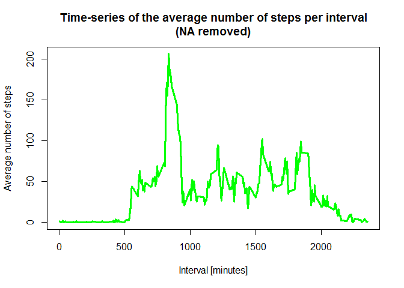

```r
## Determine the means across each interval
 mean_steps <- aggregate(activityData$steps,
                       by=list(activityData$interval),
                       FUN=mean,
                       na.rm=TRUE)
names(mean_steps)<- c("interval", "mean")
## Develop a time series plot and answer the question
plot(mean_steps$interval,
    mean_steps$mean,
      type="l",
      col="green",
     lwd=3,
      xlab="Interval [minutes]",
     ylab="Average number of steps",
      main="Time-series of the average number of steps per interval\n(NA removed)")
```

**What is that peak interval?**

```r
## Find the maximum mean and determine which interval it is in
## R studio had no problem using the max function with missing values, but KnitR did not like it
RobustMax <- function(x) {if (length(x)>0) max(x) else -Inf}
themax_Mean<- which(mean_steps$means ==RobustMax(mean_steps$means))
themax_Interval<- mean_steps[themax_Mean,1]
```

The answer is interval **835**

## Imputing Missing Values

**Calculate and report the total number of missing values in the data set.**

```r
##Count the missing values
countthe_NAs<- sum(is.na(activityData$steps))
countthe_NAs
```

```
## [1] 2304
```

```r
##Determine where the missing values are
wherethe_NAs<- which(is.na(activityData$steps))
##Use the mean of the number steps to fill in the missing values
more_means<- rep(mean(activityData$steps, na.rm=TRUE), times=length(wherethe_NAs))
## And now we have an updated data set to plot
activityData[wherethe_NAs, "steps"] <- more_means
```

**Make a new histogram and calculate and report the mean and median**

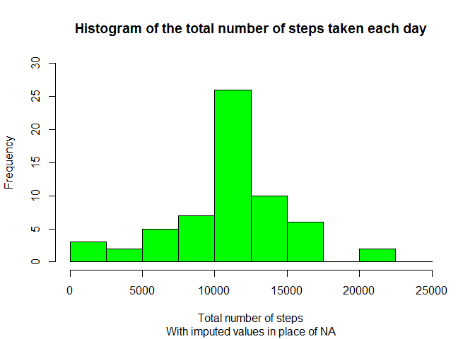

```r
newsum_steps<- aggregate(activityData$steps, by=list(activityData$date), FUN=sum)
names(newsum_steps)<- c("date", "total")
hist(newsum_steps$total,
    breaks=seq(from=0, to=25000, by=2500),
      col="green",
      xlab="Total number of steps",
      ylim=c(0, 30),
      main="Histogram of the total number of steps taken each day", sub="With imputed values in place of NA")
```

Here are the mean and median for the new data

```r
mean(newsum_steps$total)
```

```
## [1] 10766.19
```

```r
median(newsum_steps$total)
```

```
## [1] 10766.19
```

## Are there different activity patterns for weekdays and weekend?

**Create a new factor variable in the dataset to indicate weekday and weekend**

```r
##Differentiate between weekdays and the weekend
activityData2<- activityData%>%
   mutate(weektype= ifelse(weekdays(activityData$date)=="Saturday" | weekdays(activityData$date)=="Sunday", "Weekend", "Weekday"))
```

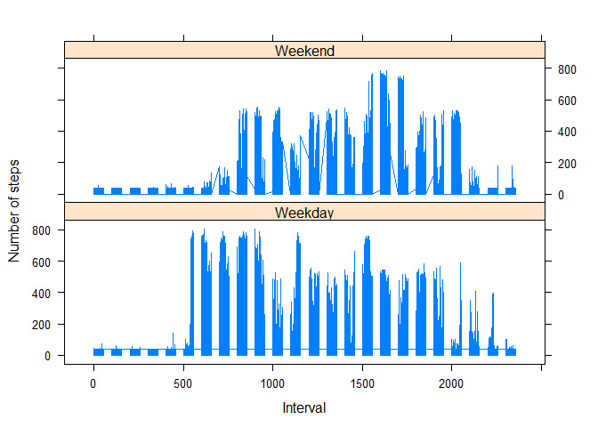

```r
mean_data <- aggregate(activityData2$steps,
                       by=list(activityData2$weektype,
                               activityData2$date, activityData2$interval), mean)

names(mean_data) <- c("daytype", "Date", "interval", "mean")


xyplot(mean ~ interval | daytype, mean_data,
       type="l",
       lwd=1,
       xlab="Interval",
       ylab="Number of steps",
       layout=c(1,2))
```